# Lab 1

Alonzo Finch

## Initializing R

When starting a new assignment or project in R, I recommend using R Markdown (file type .Rmd). R Markdown has some advantages over R script files (file type .R), such as running blocks of code, being able to see the output of your code chunks, including text in addition to R code in your file, and (most importantly) the ability to export your R output as an HTML or PDF document.

This is an R markdown file.

Below are three different examples of code chunks. Note that you can name chunks by including text after the r designation in the brackets. Ex. {r test}

The flags include after the comma tell markdown how to render the code chunk. The flag *include* determines whether the chunk and its output will be included in the render. *include = F* will not render either.

The flag *echo = F* will render the output but not the code chunk itself.

The flag *warning = F* will suppress any warnings that are included in the output.

```r
# This is how you type comments in your R code. Comments don't produce an output but act as a note separating or explaining what's written.
```

The flags above are all set to false, which is done by using **F** or **FALSE**. They can be set equal using **T*** or **TRUE**.

## Loading Packages

Below is a chunk of R code. This code chunk loads the packages we will be using for this lab. It is important to remember that to use a package in R, you must download the package to you system **and** load the package in R like below.

```r
library(readr)
library(stringr)
library(ggplot2)
library(tidyverse)
library(tigris)
#require(tigris) #represents an alternative method. Returns a warning instead of an error if a package is not installed
```

## Loading Data

Below is a chunk demonstrating how to load data in R. The first line uses traditional R syntax to load the CDC PLACES dataset. R comes installed with several built in functions and features, one of which is the function **read.csv** (type ?read.csv in the console to learn more about the function). The other datasets are loaded using **read_csv** from the **readr** package. **readr** provides some nice options for reading and writing datasets that are useful for more complicated projects.

The chunk below also includes two equivalent versions of variable assignment. You can name a variable anything (as long as it doesn’t start with a number) and assign values using **=** or **<-**. The lines below assign the output of the function to a variable. In R Markdown, all assigned variables appear in your *Environment* window.

```r
places <- read.csv("data/cdc_places_dc.csv")
dp02 = read_csv("data/acs_dp02_data.csv", show_col_types = F)
dp03 = read_csv("data/acs_dp03_data.csv", show_col_types = F)
dp04 = read_csv("data/acs_dp04_data.csv", show_col_types = F)
dp05 = read_csv("data/acs_dp05_data.csv", show_col_types = F)
```

## Exploratory Data Analysis

### CDC PLACES

Once you have the dataset loaded, I like to first look at a small snippet of the data and get a sense of what information it contains. For this part I will be focusing on the CDC PLACES data. Below are three functions that are useful for this task. **head** allows you to look at the first few rows of a datatable. There is also a corresponding function **tail**. **colnames** gets a list of the column names of the dataset. **dim** gets the dimensions of the datatable, which lets us know how many rows and columns we have in our dataset.

```r
head(places)
```

|  | Year | StateAbbr | StateDesc | CountyName | CountyFIPS | LocationName | DataSource | Category | Measure | Data_Value_Unit | Data_Value_Type | Data_Value | Data_Value_Footnote_Symbol | Data_Value_Footnote | Low_Confidence_Limit | High_Confidence_Limit | TotalPopulation | TotalPop18plus | Geolocation | LocationID | CategoryID | MeasureId | DataValueTypeID | Short_Question_Text |
| --- | --- | --- | --- | --- | --- | --- | --- | --- | --- | --- | --- | --- | --- | --- | --- | --- | --- | --- | --- | --- | --- | --- | --- | --- |
| 1 | 2022 | DC | District of Columbia | District of Columbia | 11001 | 11001007202 | BRFSS | Health Status | Fair or poor self-rated health status among adults | % | Crude prevalence | 4.6 | NA | NA | 4.0 | 5.2 | 4303 | 4152 | POINT (-77.0070741 38.8786426) | 11001007202 | HLTHSTAT | GHLTH | CrdPrv | General Health |
| 2 | 2022 | DC | District of Columbia | District of Columbia | 11001 | 11001009505 | BRFSS | Health Risk Behaviors | Short sleep duration among adults | % | Crude prevalence | 36.2 | NA | NA | 30.6 | 42.0 | 3796 | 3118 | POINT (-77.0051999 38.9618925) | 11001009505 | RISKBEH | SLEEP | CrdPrv | Short Sleep Duration |
| 3 | 2022 | DC | District of Columbia | District of Columbia | 11001 | 11001001600 | BRFSS | Disability | Vision disability among adults | % | Crude prevalence | 3.7 | NA | NA | 3.4 | 4.0 | 4471 | 3466 | POINT (-77.0382324 38.9849725) | 11001001600 | DISABLT | VISION | CrdPrv | Vision Disability |
| 4 | 2022 | DC | District of Columbia | District of Columbia | 11001 | 11001002202 | BRFSS | Health-Related Social Needs | Housing insecurity in the past 12 months among adults | % | Crude prevalence | 15.8 | NA | NA | 14.4 | 17.5 | 3339 | 2556 | POINT (-77.0118821 38.9479653) | 11001002202 | SOCLNEED | HOUSINSECU | CrdPrv | Housing Insecurity |
| 5 | 2022 | DC | District of Columbia | District of Columbia | 11001 | 11001004704 | BRFSS | Prevention | Mammography use among women aged 50-74 years | % | Crude prevalence | 68.2 | NA | NA | 60.0 | 75.3 | 1945 | 1339 | POINT (-77.0114767 38.904566) | 11001004704 | PREVENT | MAMMOUSE | CrdPrv | Mammography |
| 6 | 2022 | DC | District of Columbia | District of Columbia | 11001 | 11001002002 | BRFSS | Health Status | Frequent physical distress among adults | % | Crude prevalence | 7.7 | NA | NA | 6.9 | 8.7 | 4072 | 3198 | POINT (-77.0310824 38.9525009) | 11001002002 | HLTHSTAT | PHLTH | CrdPrv | Frequent Physical Distress |

```r
colnames(places)
```

```
##  [1] "Year"                       "StateAbbr"
##  [3] "StateDesc"                  "CountyName"
##  [5] "CountyFIPS"                 "LocationName"
##  [7] "DataSource"                 "Category"
##  [9] "Measure"                    "Data_Value_Unit"
## [11] "Data_Value_Type"            "Data_Value"
## [13] "Data_Value_Footnote_Symbol" "Data_Value_Footnote"
## [15] "Low_Confidence_Limit"       "High_Confidence_Limit"
## [17] "TotalPopulation"            "TotalPop18plus"
## [19] "Geolocation"                "LocationID"
## [21] "CategoryID"                 "MeasureId"
## [23] "DataValueTypeID"            "Short_Question_Text"
```

```r
dim(places)
```

```
## [1] 8240   24
```

Another import part of data inspection is looking at the data type or class (e.g. string, double, integer, factor) of your columns. In the chunk below are two methods for getting the types. This is important because certain functions and methods only work on specific data types so if any are incorrect (like an integer being typed as a string), we would need to fix that problem.

```r
# str(places) #commented out due to the output containing a lot of information
sapply(places, class)
```

```
##                       Year                  StateAbbr
##                  "integer"                "character"
##                  StateDesc                 CountyName
##                "character"                "character"
##                 CountyFIPS               LocationName
##                  "integer"                  "numeric"
##                 DataSource                   Category
##                "character"                "character"
##                    Measure            Data_Value_Unit
##                "character"                "character"
##            Data_Value_Type                 Data_Value
##                "character"                  "numeric"
## Data_Value_Footnote_Symbol        Data_Value_Footnote
##                  "logical"                  "logical"
##       Low_Confidence_Limit      High_Confidence_Limit
##                  "numeric"                  "numeric"
##            TotalPopulation             TotalPop18plus
##                  "integer"                  "integer"
##                Geolocation                 LocationID
##                "character"                  "numeric"
##                 CategoryID                  MeasureId
##                "character"                "character"
##            DataValueTypeID        Short_Question_Text
##                "character"                "character"
```

Now that we’ve inspected our data, we can convert our datatable into a tibble. A tibble is a tidyverse version of a datatable which provides some useful features for data cleaning. Below is an example of a tidyverse data cleaning pipeline. We only want the variable names, their values, and the id of the census tract (often called FIPS code). We also want to pivot the data so the variables are each their own column and the census tracts are the rows.

The code chunk below performs both of these operations at once using the tidyverse syntax of pipelines. There are two different ways to indicate a pipeline. **%>%** and **|>** are both pipeline operators. Pipelines pass the object at the start (usually a tibble) to the rest of the functions as an argument automatically, saving us some typing and simplifying our code. Pipelines also allow us to call column names without the use of quotation marks, which is helpful for some applications.

```r
places_tibble = as_tibble(places) |>
  group_by(Year, LocationName,LocationID) %>%
  select(c(Year, LocationName, LocationID, Data_Value, MeasureId, TotalPopulation, TotalPop18plus, Geolocation)) %>%
  pivot_wider(names_from = MeasureId, values_from = Data_Value)
```

Now that we have something cleaner, we can look at a summary of our data using the function **summary**. **summary** is a great function for getting quick summaries of all different types of R objects, from regression outputs to datatables.

```r
summary(places_tibble)
```

```
##       Year       LocationName       LocationID      TotalPopulation
##  Min.   :2021   Min.   :1.1e+10   Min.   :1.1e+10   Min.   : 176
##  1st Qu.:2021   1st Qu.:1.1e+10   1st Qu.:1.1e+10   1st Qu.:2613
##  Median :2022   Median :1.1e+10   Median :1.1e+10   Median :3262
##  Mean   :2022   Mean   :1.1e+10   Mean   :1.1e+10   Mean   :3347
##  3rd Qu.:2022   3rd Qu.:1.1e+10   3rd Qu.:1.1e+10   3rd Qu.:3941
##  Max.   :2022   Max.   :1.1e+10   Max.   :1.1e+10   Max.   :6879
##
##  TotalPop18plus Geolocation            GHLTH           SLEEP
##  Min.   : 167   Length:412         Min.   : 4.60   Min.   :22.50
##  1st Qu.:2203   Class :character   1st Qu.: 7.70   1st Qu.:27.52
##  Median :2693   Mode  :character   Median :10.55   Median :31.95
##  Mean   :2792                      Mean   :13.41   Mean   :33.63
##  3rd Qu.:3316                      3rd Qu.:18.68   3rd Qu.:39.65
##  Max.   :6779                      Max.   :35.80   Max.   :50.30
##                                    NA's   :206     NA's   :206
##      VISION         HOUSINSECU       MAMMOUSE         PHLTH
##  Min.   : 1.500   Min.   : 3.40   Min.   :58.70   Min.   : 4.200
##  1st Qu.: 2.600   1st Qu.: 6.50   1st Qu.:75.42   1st Qu.: 6.200
##  Median : 3.700   Median :10.70   Median :77.65   Median : 7.750
##  Mean   : 5.073   Mean   :14.24   Mean   :76.85   Mean   : 8.986
##  3rd Qu.: 7.000   3rd Qu.:20.25   3rd Qu.:79.28   3rd Qu.:11.375
##  Max.   :15.400   Max.   :42.60   Max.   :83.70   Max.   :17.900
##  NA's   :206      NA's   :206     NA's   :206     NA's   :206
##     HIGHCHOL        ACCESS2          CASTHMA          MHLTH
##  Min.   :12.40   Min.   : 2.300   Min.   : 8.40   Min.   : 8.50
##  1st Qu.:25.50   1st Qu.: 3.600   1st Qu.: 9.40   1st Qu.:12.93
##  Median :29.40   Median : 5.350   Median :10.25   Median :14.35
##  Mean   :28.82   Mean   : 6.232   Mean   :10.90   Mean   :15.46
##  3rd Qu.:32.60   3rd Qu.: 8.300   3rd Qu.:12.35   3rd Qu.:17.45
##  Max.   :38.40   Max.   :21.700   Max.   :16.20   Max.   :32.40
##  NA's   :206     NA's   :206      NA's   :206     NA's   :206
##   COLON_SCREEN       BPHIGH        FOODSTAMP        TEETHLOST
##  Min.   :40.10   Min.   : 8.40   Min.   : 2.400   Min.   : 2.40
##  1st Qu.:66.60   1st Qu.:19.70   1st Qu.: 5.025   1st Qu.: 4.60
##  Median :70.15   Median :25.70   Median : 9.600   Median : 8.25
##  Mean   :69.27   Mean   :28.00   Mean   :17.020   Mean   :11.83
##  3rd Qu.:73.38   3rd Qu.:37.38   3rd Qu.:25.500   3rd Qu.:16.30
##  Max.   :79.40   Max.   :45.90   Max.   :72.300   Max.   :51.30
##  NA's   :206     NA's   :206     NA's   :206      NA's   :206
```

[output cut: 41 more lines]

```
##  Min.   : 4.20   Min.   : 1.90   Min.   :19.30   Min.   :10.20
##  1st Qu.: 7.00   1st Qu.: 4.90   1st Qu.:64.70   1st Qu.:14.90
##  Median : 9.60   Median : 7.20   Median :70.70   Median :18.80
##  Mean   :11.92   Mean   : 8.30   Mean   :68.92   Mean   :21.39
##  3rd Qu.:15.85   3rd Qu.:12.07   3rd Qu.:75.47   3rd Qu.:27.75
##  Max.   :37.20   Max.   :17.30   Max.   :81.40   Max.   :42.60
##  NA's   :206     NA's   :206     NA's   :206     NA's   :206
##    EMOTIONSPT     SHUTUTILITY
##  Min.   :15.80   Min.   : 2.10
##  1st Qu.:19.80   1st Qu.: 3.60
##  Median :23.45   Median : 5.90
##  Mean   :24.72   Mean   : 8.54
##  3rd Qu.:29.48   3rd Qu.:11.93
##  Max.   :38.20   Max.   :31.30
##  NA's   :206     NA's   :206
```

Because we have two years available to us, we will choose only one for now.

```r
places = places_tibble %>% ungroup() %>% filter(Year == 2022) %>% select(!c("LocationID", "Year")) %>% rename(geoid = LocationName)
summary(places)
```

```
##      geoid         TotalPopulation TotalPop18plus Geolocation
##  Min.   :1.1e+10   Min.   : 176    Min.   : 167   Length:206
##  1st Qu.:1.1e+10   1st Qu.:2613    1st Qu.:2205   Class :character
##  Median :1.1e+10   Median :3262    Median :2693   Mode  :character
##  Mean   :1.1e+10   Mean   :3347    Mean   :2792
##  3rd Qu.:1.1e+10   3rd Qu.:3939    3rd Qu.:3315
##  Max.   :1.1e+10   Max.   :6879    Max.   :6779
##
##      GHLTH           SLEEP           VISION         HOUSINSECU
##  Min.   : 4.60   Min.   :22.50   Min.   : 1.500   Min.   : 3.40
##  1st Qu.: 7.70   1st Qu.:27.52   1st Qu.: 2.600   1st Qu.: 6.50
##  Median :10.55   Median :31.95   Median : 3.700   Median :10.70
##  Mean   :13.41   Mean   :33.63   Mean   : 5.073   Mean   :14.24
##  3rd Qu.:18.68   3rd Qu.:39.65   3rd Qu.: 7.000   3rd Qu.:20.25
##  Max.   :35.80   Max.   :50.30   Max.   :15.400   Max.   :42.60
##
##     MAMMOUSE         PHLTH           HIGHCHOL      ACCESS2
##  Min.   :58.70   Min.   : 4.200   Min.   : NA   Min.   : 2.300
##  1st Qu.:75.42   1st Qu.: 6.200   1st Qu.: NA   1st Qu.: 3.600
##  Median :77.65   Median : 7.750   Median : NA   Median : 5.350
##  Mean   :76.85   Mean   : 8.986   Mean   :NaN   Mean   : 6.232
##  3rd Qu.:79.28   3rd Qu.:11.375   3rd Qu.: NA   3rd Qu.: 8.300
##  Max.   :83.70   Max.   :17.900   Max.   : NA   Max.   :21.700
##                                   NA's   :206
##     CASTHMA          MHLTH        COLON_SCREEN       BPHIGH      FOODSTAMP
##  Min.   : 8.40   Min.   : 8.50   Min.   :40.10   Min.   : NA   Min.   : 2.400
##  1st Qu.: 9.40   1st Qu.:12.93   1st Qu.:66.60   1st Qu.: NA   1st Qu.: 5.025
##  Median :10.25   Median :14.35   Median :70.15   Median : NA   Median : 9.600
##  Mean   :10.90   Mean   :15.46   Mean   :69.27   Mean   :NaN   Mean   :17.020
##  3rd Qu.:12.35   3rd Qu.:17.45   3rd Qu.:73.38   3rd Qu.: NA   3rd Qu.:25.500
##  Max.   :16.20   Max.   :32.40   Max.   :79.40   Max.   : NA   Max.   :72.300
##                                                  NA's   :206
##    TEETHLOST       INDEPLIVE        FOODINSECU        BINGE
##  Min.   : 2.40   Min.   : 2.700   Min.   : 3.00   Min.   :15.70
##  1st Qu.: 4.60   1st Qu.: 4.000   1st Qu.: 5.80   1st Qu.:19.70
##  Median : 8.25   Median : 5.300   Median :10.05   Median :24.75
##  Mean   :11.83   Mean   : 6.960   Mean   :15.18   Mean   :24.65
##  3rd Qu.:16.30   3rd Qu.: 9.475   3rd Qu.:22.73   3rd Qu.:29.18
##  Max.   :51.30   Max.   :19.700   Max.   :55.60   Max.   :36.50
##
```

[output cut: 33 more lines]

```
##  Min.   :0.700   Min.   : 4.20   Min.   : 1.90   Min.   : NA   Min.   :10.20
##  1st Qu.:1.700   1st Qu.: 7.00   1st Qu.: 4.90   1st Qu.: NA   1st Qu.:14.90
##  Median :2.500   Median : 9.60   Median : 7.20   Median : NA   Median :18.80
##  Mean   :3.009   Mean   :11.92   Mean   : 8.30   Mean   :NaN   Mean   :21.39
##  3rd Qu.:4.400   3rd Qu.:15.85   3rd Qu.:12.07   3rd Qu.: NA   3rd Qu.:27.75
##  Max.   :7.200   Max.   :37.20   Max.   :17.30   Max.   : NA   Max.   :42.60
##                                                  NA's   :206
##    EMOTIONSPT     SHUTUTILITY
##  Min.   :15.80   Min.   : 2.10
##  1st Qu.:19.80   1st Qu.: 3.60
##  Median :23.45   Median : 5.90
##  Mean   :24.72   Mean   : 8.54
##  3rd Qu.:29.48   3rd Qu.:11.93
##  Max.   :38.20   Max.   :31.30
##
```

### ACS Data

We’ll now do the same procedure above for the American Community Survey Data.

If you inspected the csv file (for instance in excel), you’d see that the first two rows are both column names. The actually descriptive column name is row 2, so we will use one of the features of **read_csv** from **readr** to skip the first row.

```r
dp02 = read_csv("data/acs_dp02_data.csv", skip = 1, show_col_types = F)
dp03 = read_csv("data/acs_dp03_data.csv", skip = 1, show_col_types = F)
dp04 = read_csv("data/acs_dp04_data.csv", skip = 1, show_col_types = F)
dp05 = read_csv("data/acs_dp05_data.csv", skip = 1, show_col_types = F)
```

[output not shown]

#### DP02

```r
head(dp02)
```

| Geography | Geographic Area Name | Estimate!!HOUSEHOLDS BY TYPE!!Total households | Margin of Error!!HOUSEHOLDS BY TYPE!!Total households | Estimate!!HOUSEHOLDS BY TYPE!!Total households!!Married-couple household | Margin of Error!!HOUSEHOLDS BY TYPE!!Total households!!Married-couple household | Estimate!!HOUSEHOLDS BY TYPE!!Total households!!Married-couple household!!With children of the householder under 18 years | Margin of Error!!HOUSEHOLDS BY TYPE!!Total households!!Married-couple household!!With children of the householder under 18 years | Estimate!!HOUSEHOLDS BY TYPE!!Total households!!Cohabiting couple household | Margin of Error!!HOUSEHOLDS BY TYPE!!Total households!!Cohabiting couple household | Estimate!!HOUSEHOLDS BY TYPE!!Total households!!Cohabiting couple household!!With children of the householder under 18 years | Margin of Error!!HOUSEHOLDS BY TYPE!!Total households!!Cohabiting couple household!!With children of the householder under 18 years | Estimate!!HOUSEHOLDS BY TYPE!!Total households!!Male householder, no spouse/partner present | Margin of Error!!HOUSEHOLDS BY TYPE!!Total households!!Male householder, no spouse/partner present | Estimate!!HOUSEHOLDS BY TYPE!!Total households!!Male householder, no spouse/partner present!!With children of the householder under 18 years | Margin of Error!!HOUSEHOLDS BY TYPE!!Total households!!Male householder, no spouse/partner present!!With children of the householder under 18 years | Estimate!!HOUSEHOLDS BY TYPE!!Total households!!Male householder, no spouse/partner present!!Householder living alone | Margin of Error!!HOUSEHOLDS BY TYPE!!Total households!!Male householder, no spouse/partner present!!Householder living alone | Estimate!!HOUSEHOLDS BY TYPE!!Total households!!Male householder, no spouse/partner present!!Householder living alone!!65 years and over | Margin of Error!!HOUSEHOLDS BY TYPE!!Total households!!Male householder, no spouse/partner present!!Householder living alone!!65 years and over | Estimate!!HOUSEHOLDS BY TYPE!!Total households!!Female householder, no spouse/partner present | Margin of Error!!HOUSEHOLDS BY TYPE!!Total households!!Female householder, no spouse/partner present | Estimate!!HOUSEHOLDS BY TYPE!!Total households!!Female householder, no spouse/partner present!!With children of the householder under 18 years | Margin of Error!!HOUSEHOLDS BY TYPE!!Total households!!Female householder, no spouse/partner present!!With children of the householder under 18 years | Estimate!!HOUSEHOLDS BY TYPE!!Total households!!Female householder, no spouse/partner present!!Householder living alone | Margin of Error!!HOUSEHOLDS BY TYPE!!Total households!!Female householder, no spouse/partner present!!Householder living alone | Estimate!!HOUSEHOLDS BY TYPE!!Total households!!Female householder, no spouse/partner present!!Householder living alone!!65 years and over | Margin of Error!!HOUSEHOLDS BY TYPE!!Total households!!Female householder, no spouse/partner present!!Householder living alone!!65 years and over | Estimate!!HOUSEHOLDS BY TYPE!!Total households!!Households with one or more people under 18 years | Margin of Error!!HOUSEHOLDS BY TYPE!!Total households!!Households with one or more people under 18 years | … |
| --- | --- | --- | --- | --- | --- | --- | --- | --- | --- | --- | --- | --- | --- | --- | --- | --- | --- | --- | --- | --- | --- | --- | --- | --- | --- | --- | --- | --- | --- | --- |
| 1400000US11001000101 | Census Tract 1.01; District of Columbia; District of Columbia | 803 | 128 | 219 | 86 | 50 | 17 | 35 | 40 | 0 | 14 | 179 | 97 | 0 | 14 | 179 | 97 | 121 | 81 | 370 | 127 | 0 | 14 | 370 | 127 | 91 | 55 | 50 | 17 | … |
| 1400000US11001000102 | Census Tract 1.02; District of Columbia; District of Columbia | 1830 | 325 | 829 | 193 | 184 | 95 | 42 | 43 | 0 | 14 | 266 | 168 | 0 | 14 | 240 | 165 | 67 | 56 | 693 | 259 | 22 | 35 | 588 | 256 | 252 | 144 | 206 | 98 | … |
| 1400000US11001000201 | Census Tract 2.01; District of Columbia; District of Columbia | 0 | 14 | 0 | 14 | 0 | 14 | 0 | 14 | 0 | 14 | 0 | 14 | 0 | 14 | 0 | 14 | 0 | 14 | 0 | 14 | 0 | 14 | 0 | 14 | 0 | 14 | 0 | 14 | … |
| 1400000US11001000202 | Census Tract 2.02; District of Columbia; District of Columbia | 1832 | 355 | 537 | 148 | 199 | 100 | 92 | 68 | 0 | 14 | 408 | 126 | 0 | 14 | 180 | 92 | 78 | 49 | 795 | 329 | 0 | 14 | 687 | 345 | 166 | 89 | 199 | 100 | … |
| 1400000US11001000300 | Census Tract 3; District of Columbia; District of Columbia | 2430 | 274 | 1073 | 209 | 626 | 194 | 146 | 113 | 0 | 20 | 489 | 202 | 0 | 20 | 369 | 200 | 172 | 171 | 722 | 155 | 77 | 77 | 436 | 117 | 203 | 88 | 703 | 198 | … |
| 1400000US11001000400 | Census Tract 4; District of Columbia; District of Columbia | 698 | 75 | 322 | 71 | 111 | 62 | 48 | 30 | 0 | 14 | 132 | 47 | 6 | 10 | 72 | 33 | 14 | 15 | 196 | 60 | 11 | 12 | 141 | 52 | 60 | 52 | 145 | 60 | … |

```r
colnames(dp02)
```

```
##   [1] "Geography"
##   [2] "Geographic Area Name"
##   [3] "Estimate!!HOUSEHOLDS BY TYPE!!Total households"
##   [4] "Margin of Error!!HOUSEHOLDS BY TYPE!!Total households"
##   [5] "Estimate!!HOUSEHOLDS BY TYPE!!Total households!!Married-couple household"
##   [6] "Margin of Error!!HOUSEHOLDS BY TYPE!!Total households!!Married-couple household"
##   [7] "Estimate!!HOUSEHOLDS BY TYPE!!Total households!!Married-couple household!!With children of the householder under 18 years"
##   [8] "Margin of Error!!HOUSEHOLDS BY TYPE!!Total households!!Married-couple household!!With children of the householder under 18 years"
##   [9] "Estimate!!HOUSEHOLDS BY TYPE!!Total households!!Cohabiting couple household"
##  [10] "Margin of Error!!HOUSEHOLDS BY TYPE!!Total households!!Cohabiting couple household"
##  [11] "Estimate!!HOUSEHOLDS BY TYPE!!Total households!!Cohabiting couple household!!With children of the householder under 18 years"
##  [12] "Margin of Error!!HOUSEHOLDS BY TYPE!!Total households!!Cohabiting couple household!!With children of the householder under 18 years"
##  [13] "Estimate!!HOUSEHOLDS BY TYPE!!Total households!!Male householder, no spouse/partner present"
##  [14] "Margin of Error!!HOUSEHOLDS BY TYPE!!Total households!!Male householder, no spouse/partner present"
##  [15] "Estimate!!HOUSEHOLDS BY TYPE!!Total households!!Male householder, no spouse/partner present!!With children of the householder under 18 years"
```

[output cut: 604 more lines]

```r
dim(dp02)
```

```
## [1] 206 619
```

```r
sapply(dp02, class)
```

```
##                                                                                                                                                                                       Geography
##                                                                                                                                                                                     "character"
##                                                                                                                                                                            Geographic Area Name
##                                                                                                                                                                                     "character"
##                                                                                                                                                  Estimate!!HOUSEHOLDS BY TYPE!!Total households
##                                                                                                                                                                                       "numeric"
##                                                                                                                                           Margin of Error!!HOUSEHOLDS BY TYPE!!Total households
##                                                                                                                                                                                       "numeric"
##                                                                                                                        Estimate!!HOUSEHOLDS BY TYPE!!Total households!!Married-couple household
##                                                                                                                                                                                       "numeric"
##                                                                                                                 Margin of Error!!HOUSEHOLDS BY TYPE!!Total households!!Married-couple household
##                                                                                                                                                                                       "numeric"
##                                                                       Estimate!!HOUSEHOLDS BY TYPE!!Total households!!Married-couple household!!With children of the householder under 18 years
##                                                                                                                                                                                       "numeric"
##                                                                Margin of Error!!HOUSEHOLDS BY TYPE!!Total households!!Married-couple household!!With children of the householder under 18 years
##                                                                                                                                                                                       "numeric"
##                                                                                                                     Estimate!!HOUSEHOLDS BY TYPE!!Total households!!Cohabiting couple household
##                                                                                                                                                                                       "numeric"
##                                                                                                              Margin of Error!!HOUSEHOLDS BY TYPE!!Total households!!Cohabiting couple household
##                                                                                                                                                                                       "numeric"
##                                                                    Estimate!!HOUSEHOLDS BY TYPE!!Total households!!Cohabiting couple household!!With children of the householder under 18 years
##                                                                                                                                                                                       "numeric"
##                                                             Margin of Error!!HOUSEHOLDS BY TYPE!!Total households!!Cohabiting couple household!!With children of the householder under 18 years
##                                                                                                                                                                                       "numeric"
##                                                                                                     Estimate!!HOUSEHOLDS BY TYPE!!Total households!!Male householder, no spouse/partner present
##                                                                                                                                                                                       "numeric"
```

[output cut: 1212 more lines]

```r
dp02_tibble = as_tibble(dp02) %>%
  select(!contains("Margin of Error!!")) %>%
  select(!contains("Percent!!")) %>%
  select(!contains("Percent Margin of Error!!")) %>%
  mutate(Geography = str_remove(Geography, "1400000US")) %>%
  select(!c("Geographic Area Name")) %>%
  rename(geoid = Geography) %>%
  mutate(geoid = as.numeric(geoid))
```

```r
dp02 = dp02_tibble
```

#### DP03

```r
head(dp03)
```

| Geography | Geographic Area Name | Estimate!!EMPLOYMENT STATUS!!Population 16 years and over | Margin of Error!!EMPLOYMENT STATUS!!Population 16 years and over | Estimate!!EMPLOYMENT STATUS!!Population 16 years and over!!In labor force | Margin of Error!!EMPLOYMENT STATUS!!Population 16 years and over!!In labor force | Estimate!!EMPLOYMENT STATUS!!Population 16 years and over!!In labor force!!Civilian labor force | Margin of Error!!EMPLOYMENT STATUS!!Population 16 years and over!!In labor force!!Civilian labor force | Estimate!!EMPLOYMENT STATUS!!Population 16 years and over!!In labor force!!Civilian labor force!!Employed | Margin of Error!!EMPLOYMENT STATUS!!Population 16 years and over!!In labor force!!Civilian labor force!!Employed | Estimate!!EMPLOYMENT STATUS!!Population 16 years and over!!In labor force!!Civilian labor force!!Unemployed | Margin of Error!!EMPLOYMENT STATUS!!Population 16 years and over!!In labor force!!Civilian labor force!!Unemployed | Estimate!!EMPLOYMENT STATUS!!Population 16 years and over!!In labor force!!Armed Forces | Margin of Error!!EMPLOYMENT STATUS!!Population 16 years and over!!In labor force!!Armed Forces | Estimate!!EMPLOYMENT STATUS!!Population 16 years and over!!Not in labor force | Margin of Error!!EMPLOYMENT STATUS!!Population 16 years and over!!Not in labor force | Estimate!!EMPLOYMENT STATUS!!Civilian labor force | Margin of Error!!EMPLOYMENT STATUS!!Civilian labor force | Estimate!!EMPLOYMENT STATUS!!Civilian labor force!!Unemployment Rate | Margin of Error!!EMPLOYMENT STATUS!!Civilian labor force!!Unemployment Rate | Estimate!!EMPLOYMENT STATUS!!Females 16 years and over | Margin of Error!!EMPLOYMENT STATUS!!Females 16 years and over | Estimate!!EMPLOYMENT STATUS!!Females 16 years and over!!In labor force | Margin of Error!!EMPLOYMENT STATUS!!Females 16 years and over!!In labor force | Estimate!!EMPLOYMENT STATUS!!Females 16 years and over!!In labor force!!Civilian labor force | Margin of Error!!EMPLOYMENT STATUS!!Females 16 years and over!!In labor force!!Civilian labor force | Estimate!!EMPLOYMENT STATUS!!Females 16 years and over!!In labor force!!Civilian labor force!!Employed | Margin of Error!!EMPLOYMENT STATUS!!Females 16 years and over!!In labor force!!Civilian labor force!!Employed | Estimate!!EMPLOYMENT STATUS!!Own children of the householder under 6 years | Margin of Error!!EMPLOYMENT STATUS!!Own children of the householder under 6 years | … |
| --- | --- | --- | --- | --- | --- | --- | --- | --- | --- | --- | --- | --- | --- | --- | --- | --- | --- | --- | --- | --- | --- | --- | --- | --- | --- | --- | --- | --- | --- | --- |
| 1400000US11001000101 | Census Tract 1.01; District of Columbia; District of Columbia | 1066 | 188 | 745 | 162 | 745 | 162 | 728 | 158 | 17 | 21 | 0 | 14 | 321 | 125 | 745 | 162 | (X) | (X) | 610 | 152 | 457 | 126 | 457 | 126 | 447 | 125 | 98 | 51 | … |
| 1400000US11001000102 | Census Tract 1.02; District of Columbia; District of Columbia | 2807 | 362 | 1960 | 334 | 1960 | 334 | 1926 | 334 | 34 | 40 | 0 | 14 | 847 | 241 | 1960 | 334 | (X) | (X) | 1494 | 305 | 977 | 277 | 977 | 277 | 971 | 276 | 135 | 83 | … |
| 1400000US11001000201 | Census Tract 2.01; District of Columbia; District of Columbia | 2835 | 45 | 1082 | 196 | 1082 | 196 | 950 | 181 | 132 | 76 | 0 | 14 | 1753 | 200 | 1082 | 196 | (X) | (X) | 1705 | 125 | 790 | 152 | 790 | 152 | 680 | 147 | 0 | 14 | … |
| 1400000US11001000202 | Census Tract 2.02; District of Columbia; District of Columbia | 3762 | 483 | 2495 | 418 | 2477 | 419 | 2391 | 411 | 86 | 54 | 18 | 23 | 1267 | 257 | 2477 | 419 | (X) | (X) | 2049 | 374 | 1383 | 348 | 1373 | 348 | 1315 | 347 | 87 | 53 | … |
| 1400000US11001000300 | Census Tract 3; District of Columbia; District of Columbia | 4632 | 590 | 3393 | 437 | 3393 | 437 | 3357 | 429 | 36 | 40 | 0 | 20 | 1239 | 350 | 3393 | 437 | (X) | (X) | 2356 | 334 | 1795 | 317 | 1795 | 317 | 1781 | 314 | 473 | 204 | … |
| 1400000US11001000400 | Census Tract 4; District of Columbia; District of Columbia | 1417 | 199 | 797 | 139 | 797 | 139 | 726 | 128 | 71 | 42 | 0 | 14 | 620 | 136 | 797 | 139 | (X) | (X) | 696 | 123 | 357 | 79 | 357 | 79 | 344 | 77 | 39 | 27 | … |

```r
colnames(dp03)
```

```
##   [1] "Geography"
##   [2] "Geographic Area Name"
##   [3] "Estimate!!EMPLOYMENT STATUS!!Population 16 years and over"
##   [4] "Margin of Error!!EMPLOYMENT STATUS!!Population 16 years and over"
##   [5] "Estimate!!EMPLOYMENT STATUS!!Population 16 years and over!!In labor force"
##   [6] "Margin of Error!!EMPLOYMENT STATUS!!Population 16 years and over!!In labor force"
##   [7] "Estimate!!EMPLOYMENT STATUS!!Population 16 years and over!!In labor force!!Civilian labor force"
##   [8] "Margin of Error!!EMPLOYMENT STATUS!!Population 16 years and over!!In labor force!!Civilian labor force"
##   [9] "Estimate!!EMPLOYMENT STATUS!!Population 16 years and over!!In labor force!!Civilian labor force!!Employed"
##  [10] "Margin of Error!!EMPLOYMENT STATUS!!Population 16 years and over!!In labor force!!Civilian labor force!!Employed"
##  [11] "Estimate!!EMPLOYMENT STATUS!!Population 16 years and over!!In labor force!!Civilian labor force!!Unemployed"
##  [12] "Margin of Error!!EMPLOYMENT STATUS!!Population 16 years and over!!In labor force!!Civilian labor force!!Unemployed"
##  [13] "Estimate!!EMPLOYMENT STATUS!!Population 16 years and over!!In labor force!!Armed Forces"
##  [14] "Margin of Error!!EMPLOYMENT STATUS!!Population 16 years and over!!In labor force!!Armed Forces"
##  [15] "Estimate!!EMPLOYMENT STATUS!!Population 16 years and over!!Not in labor force"
```

[output cut: 536 more lines]

```r
dim(dp03)
```

```
## [1] 206 551
```

```r
sapply(dp03, class)
```

```
##                                                                                                                                                                                                                                                                                                         G…
##                                                                                                                                                                                                                                                                                                       "ch…
##                                                                                                                                                                                                                                                                                              Geographic A…
##                                                                                                                                                                                                                                                                                                       "ch…
##                                                                                                                                                                                                                                                         Estimate!!EMPLOYMENT STATUS!!Population 16 years …
##                                                                                                                                                                                                                                                                                                         "…
##                                                                                                                                                                                                                                                  Margin of Error!!EMPLOYMENT STATUS!!Population 16 years …
##                                                                                                                                                                                                                                                                                                         "…
##                                                                                                                                                                                                                                         Estimate!!EMPLOYMENT STATUS!!Population 16 years and over!!In lab…
##                                                                                                                                                                                                                                                                                                         "…
##                                                                                                                                                                                                                                  Margin of Error!!EMPLOYMENT STATUS!!Population 16 years and over!!In lab…
##                                                                                                                                                                                                                                                                                                         "…
##                                                                                                                                                                                                                   Estimate!!EMPLOYMENT STATUS!!Population 16 years and over!!In labor force!!Civilian lab…
##                                                                                                                                                                                                                                                                                                         "…
##                                                                                                                                                                                                            Margin of Error!!EMPLOYMENT STATUS!!Population 16 years and over!!In labor force!!Civilian lab…
##                                                                                                                                                                                                                                                                                                         "…
##                                                                                                                                                                                                         Estimate!!EMPLOYMENT STATUS!!Population 16 years and over!!In labor force!!Civilian labor force!!…
```

[output cut: 1085 more lines]

```r
dp03_tibble = as_tibble(dp03) %>%
  select(!contains("Margin of Error!!")) %>%
  select(!contains("Percent!!")) %>%
  select(!contains("Percent Margin of Error!!")) %>%
  mutate(Geography = str_remove(Geography, "1400000US")) %>%
  select(!c("Geographic Area Name")) %>%
  rename(geoid = Geography) %>%
  mutate(geoid = as.numeric(geoid))
```

```r
dp03 = dp03_tibble
```

#### DP04

```r
head(dp04)
```

| Geography | Geographic Area Name | Estimate!!HOUSING OCCUPANCY!!Total housing units | Margin of Error!!HOUSING OCCUPANCY!!Total housing units | Estimate!!HOUSING OCCUPANCY!!Total housing units!!Occupied housing units | Margin of Error!!HOUSING OCCUPANCY!!Total housing units!!Occupied housing units | Estimate!!HOUSING OCCUPANCY!!Total housing units!!Vacant housing units | Margin of Error!!HOUSING OCCUPANCY!!Total housing units!!Vacant housing units | Estimate!!HOUSING OCCUPANCY!!Total housing units!!Homeowner vacancy rate | Margin of Error!!HOUSING OCCUPANCY!!Total housing units!!Homeowner vacancy rate | Estimate!!HOUSING OCCUPANCY!!Total housing units!!Rental vacancy rate | Margin of Error!!HOUSING OCCUPANCY!!Total housing units!!Rental vacancy rate | Estimate!!UNITS IN STRUCTURE!!Total housing units | Margin of Error!!UNITS IN STRUCTURE!!Total housing units | Estimate!!UNITS IN STRUCTURE!!Total housing units!!1-unit, detached | Margin of Error!!UNITS IN STRUCTURE!!Total housing units!!1-unit, detached | Estimate!!UNITS IN STRUCTURE!!Total housing units!!1-unit, attached | Margin of Error!!UNITS IN STRUCTURE!!Total housing units!!1-unit, attached | Estimate!!UNITS IN STRUCTURE!!Total housing units!!2 units | Margin of Error!!UNITS IN STRUCTURE!!Total housing units!!2 units | Estimate!!UNITS IN STRUCTURE!!Total housing units!!3 or 4 units | Margin of Error!!UNITS IN STRUCTURE!!Total housing units!!3 or 4 units | Estimate!!UNITS IN STRUCTURE!!Total housing units!!5 to 9 units | Margin of Error!!UNITS IN STRUCTURE!!Total housing units!!5 to 9 units | Estimate!!UNITS IN STRUCTURE!!Total housing units!!10 to 19 units | Margin of Error!!UNITS IN STRUCTURE!!Total housing units!!10 to 19 units | Estimate!!UNITS IN STRUCTURE!!Total housing units!!20 or more units | Margin of Error!!UNITS IN STRUCTURE!!Total housing units!!20 or more units | Estimate!!UNITS IN STRUCTURE!!Total housing units!!Mobile home | Margin of Error!!UNITS IN STRUCTURE!!Total housing units!!Mobile home | … |
| --- | --- | --- | --- | --- | --- | --- | --- | --- | --- | --- | --- | --- | --- | --- | --- | --- | --- | --- | --- | --- | --- | --- | --- | --- | --- | --- | --- | --- | --- | --- |
| 1400000US11001000101 | Census Tract 1.01; District of Columbia; District of Columbia | 898 | 96 | 803 | 128 | 95 | 92 | 0.0 | 10.0 | 12.7 | 18.5 | 898 | 96 | 5 | 7 | 250 | 103 | 0 | 14 | 21 | 24 | 0 | 14 | 8 | 12 | 614 | 96 | 0 | 14 | … |
| 1400000US11001000102 | Census Tract 1.02; District of Columbia; District of Columbia | 2207 | 288 | 1830 | 325 | 377 | 161 | 0.7 | 1.3 | 11.0 | 10.2 | 2207 | 288 | 138 | 95 | 1131 | 255 | 205 | 215 | 193 | 122 | 48 | 47 | 113 | 99 | 379 | 202 | 0 | 14 | … |
| 1400000US11001000201 | Census Tract 2.01; District of Columbia; District of Columbia | 0 | 14 | 0 | 14 | 0 | 14 | - | ** | - | ** | 0 | 14 | 0 | 14 | 0 | 14 | 0 | 14 | 0 | 14 | 0 | 14 | 0 | 14 | 0 | 14 | 0 | 14 | … |
| 1400000US11001000202 | Census Tract 2.02; District of Columbia; District of Columbia | 1977 | 361 | 1832 | 355 | 145 | 98 | 0.0 | 3.4 | 13.4 | 13.2 | 1977 | 361 | 156 | 87 | 1313 | 350 | 0 | 14 | 47 | 49 | 46 | 40 | 70 | 40 | 345 | 144 | 0 | 14 | … |
| 1400000US11001000300 | Census Tract 3; District of Columbia; District of Columbia | 2793 | 281 | 2430 | 274 | 363 | 204 | 4.9 | 6.2 | 0.0 | 4.3 | 2793 | 281 | 267 | 129 | 1455 | 247 | 76 | 77 | 237 | 116 | 439 | 191 | 130 | 72 | 189 | 98 | 0 | 20 | … |
| 1400000US11001000400 | Census Tract 4; District of Columbia; District of Columbia | 885 | 76 | 698 | 75 | 187 | 77 | 0.0 | 11.7 | 21.1 | 10.9 | 885 | 76 | 404 | 94 | 11 | 13 | 1 | 3 | 0 | 14 | 0 | 14 | 7 | 10 | 462 | 72 | 0 | 14 | … |

```r
colnames(dp04)
```

```
##   [1] "Geography"
##   [2] "Geographic Area Name"
##   [3] "Estimate!!HOUSING OCCUPANCY!!Total housing units"
##   [4] "Margin of Error!!HOUSING OCCUPANCY!!Total housing units"
##   [5] "Estimate!!HOUSING OCCUPANCY!!Total housing units!!Occupied housing units"
##   [6] "Margin of Error!!HOUSING OCCUPANCY!!Total housing units!!Occupied housing units"
##   [7] "Estimate!!HOUSING OCCUPANCY!!Total housing units!!Vacant housing units"
##   [8] "Margin of Error!!HOUSING OCCUPANCY!!Total housing units!!Vacant housing units"
##   [9] "Estimate!!HOUSING OCCUPANCY!!Total housing units!!Homeowner vacancy rate"
##  [10] "Margin of Error!!HOUSING OCCUPANCY!!Total housing units!!Homeowner vacancy rate"
##  [11] "Estimate!!HOUSING OCCUPANCY!!Total housing units!!Rental vacancy rate"
##  [12] "Margin of Error!!HOUSING OCCUPANCY!!Total housing units!!Rental vacancy rate"
##  [13] "Estimate!!UNITS IN STRUCTURE!!Total housing units"
##  [14] "Margin of Error!!UNITS IN STRUCTURE!!Total housing units"
##  [15] "Estimate!!UNITS IN STRUCTURE!!Total housing units!!1-unit, detached"
```

[output cut: 560 more lines]

```r
dim(dp04)
```

```
## [1] 206 575
```

```r
sapply(dp04, class)
```

```
##                                                                                                                                                                                                       Geography
##                                                                                                                                                                                                     "character"
##                                                                                                                                                                                            Geographic Area Name
##                                                                                                                                                                                                     "character"
##                                                                                                                                                                Estimate!!HOUSING OCCUPANCY!!Total housing units
##                                                                                                                                                                                                       "numeric"
##                                                                                                                                                         Margin of Error!!HOUSING OCCUPANCY!!Total housing units
##                                                                                                                                                                                                       "numeric"
##                                                                                                                                        Estimate!!HOUSING OCCUPANCY!!Total housing units!!Occupied housing units
##                                                                                                                                                                                                       "numeric"
##                                                                                                                                 Margin of Error!!HOUSING OCCUPANCY!!Total housing units!!Occupied housing units
##                                                                                                                                                                                                       "numeric"
##                                                                                                                                          Estimate!!HOUSING OCCUPANCY!!Total housing units!!Vacant housing units
##                                                                                                                                                                                                       "numeric"
##                                                                                                                                   Margin of Error!!HOUSING OCCUPANCY!!Total housing units!!Vacant housing units
##                                                                                                                                                                                                       "numeric"
##                                                                                                                                        Estimate!!HOUSING OCCUPANCY!!Total housing units!!Homeowner vacancy rate
##                                                                                                                                                                                                     "character"
##                                                                                                                                 Margin of Error!!HOUSING OCCUPANCY!!Total housing units!!Homeowner vacancy rate
##                                                                                                                                                                                                     "character"
##                                                                                                                                           Estimate!!HOUSING OCCUPANCY!!Total housing units!!Rental vacancy rate
##                                                                                                                                                                                                     "character"
##                                                                                                                                    Margin of Error!!HOUSING OCCUPANCY!!Total housing units!!Rental vacancy rate
##                                                                                                                                                                                                     "character"
##                                                                                                                                                               Estimate!!UNITS IN STRUCTURE!!Total housing units
##                                                                                                                                                                                                       "numeric"
```

[output cut: 1124 more lines]

```r
dp04_tibble = as_tibble(dp04) %>%
  select(!contains("Margin of Error!!")) %>%
  select(!contains("Percent!!")) %>%
  select(!contains("Percent Margin of Error!!")) %>%
  mutate(Geography = str_remove(Geography, "1400000US")) %>%
  select(!c("Geographic Area Name")) %>%
  rename(geoid = Geography) %>%
  mutate(geoid = as.numeric(geoid))
```

```r
dp04 = dp04_tibble
```

#### DP05

```r
head(dp05)
```

| Geography | Geographic Area Name | Estimate!!SEX AND AGE!!Total population | Margin of Error!!SEX AND AGE!!Total population | Estimate!!SEX AND AGE!!Total population!!Male | Margin of Error!!SEX AND AGE!!Total population!!Male | Estimate!!SEX AND AGE!!Total population!!Female | Margin of Error!!SEX AND AGE!!Total population!!Female | Estimate!!SEX AND AGE!!Total population!!Sex ratio (males per 100 females) | Margin of Error!!SEX AND AGE!!Total population!!Sex ratio (males per 100 females) | Estimate!!SEX AND AGE!!Total population!!Under 5 years | Margin of Error!!SEX AND AGE!!Total population!!Under 5 years | Estimate!!SEX AND AGE!!Total population!!5 to 9 years | Margin of Error!!SEX AND AGE!!Total population!!5 to 9 years | Estimate!!SEX AND AGE!!Total population!!10 to 14 years | Margin of Error!!SEX AND AGE!!Total population!!10 to 14 years | Estimate!!SEX AND AGE!!Total population!!15 to 19 years | Margin of Error!!SEX AND AGE!!Total population!!15 to 19 years | Estimate!!SEX AND AGE!!Total population!!20 to 24 years | Margin of Error!!SEX AND AGE!!Total population!!20 to 24 years | Estimate!!SEX AND AGE!!Total population!!25 to 34 years | Margin of Error!!SEX AND AGE!!Total population!!25 to 34 years | Estimate!!SEX AND AGE!!Total population!!35 to 44 years | Margin of Error!!SEX AND AGE!!Total population!!35 to 44 years | Estimate!!SEX AND AGE!!Total population!!45 to 54 years | Margin of Error!!SEX AND AGE!!Total population!!45 to 54 years | Estimate!!SEX AND AGE!!Total population!!55 to 59 years | Margin of Error!!SEX AND AGE!!Total population!!55 to 59 years | Estimate!!SEX AND AGE!!Total population!!60 to 64 years | Margin of Error!!SEX AND AGE!!Total population!!60 to 64 years | … |
| --- | --- | --- | --- | --- | --- | --- | --- | --- | --- | --- | --- | --- | --- | --- | --- | --- | --- | --- | --- | --- | --- | --- | --- | --- | --- | --- | --- | --- | --- | --- |
| 1400000US11001000101 | Census Tract 1.01; District of Columbia; District of Columbia | 1181 | 205 | 503 | 121 | 678 | 166 | 74.2 | 25.2 | 98 | 51 | 6 | 16 | 11 | 20 | 0 | 14 | 18 | 22 | 180 | 96 | 299 | 108 | 104 | 90 | 30 | 23 | 62 | 36 | … |
| 1400000US11001000102 | Census Tract 1.02; District of Columbia; District of Columbia | 3056 | 396 | 1438 | 284 | 1618 | 313 | 88.9 | 26.1 | 135 | 83 | 56 | 56 | 41 | 47 | 45 | 52 | 30 | 32 | 479 | 147 | 331 | 98 | 300 | 172 | 298 | 164 | 390 | 235 | … |
| 1400000US11001000201 | Census Tract 2.01; District of Columbia; District of Columbia | 2835 | 45 | 1130 | 130 | 1705 | 125 | 66.3 | 12.5 | 0 | 14 | 0 | 14 | 0 | 14 | 1603 | 249 | 1157 | 252 | 40 | 78 | 0 | 14 | 35 | 76 | 0 | 14 | 0 | 14 | … |
| 1400000US11001000202 | Census Tract 2.02; District of Columbia; District of Columbia | 3964 | 481 | 1849 | 272 | 2115 | 369 | 87.4 | 19.2 | 78 | 46 | 98 | 45 | 26 | 32 | 395 | 142 | 910 | 203 | 361 | 128 | 312 | 112 | 185 | 95 | 351 | 160 | 517 | 363 | … |
| 1400000US11001000300 | Census Tract 3; District of Columbia; District of Columbia | 5669 | 709 | 2694 | 425 | 2975 | 426 | 90.6 | 15.2 | 431 | 206 | 310 | 135 | 253 | 130 | 416 | 269 | 494 | 163 | 1005 | 267 | 893 | 290 | 727 | 197 | 252 | 86 | 209 | 86 | … |
| 1400000US11001000400 | Census Tract 4; District of Columbia; District of Columbia | 1715 | 318 | 818 | 129 | 897 | 255 | 91.2 | 27.4 | 80 | 50 | 48 | 34 | 158 | 156 | 48 | 26 | 68 | 37 | 255 | 129 | 162 | 51 | 257 | 143 | 126 | 47 | 159 | 91 | … |

```r
colnames(dp05)
```

```
##   [1] "Geography"
##   [2] "Geographic Area Name"
##   [3] "Estimate!!SEX AND AGE!!Total population"
##   [4] "Margin of Error!!SEX AND AGE!!Total population"
##   [5] "Estimate!!SEX AND AGE!!Total population!!Male"
##   [6] "Margin of Error!!SEX AND AGE!!Total population!!Male"
##   [7] "Estimate!!SEX AND AGE!!Total population!!Female"
##   [8] "Margin of Error!!SEX AND AGE!!Total population!!Female"
##   [9] "Estimate!!SEX AND AGE!!Total population!!Sex ratio (males per 100 females)"
##  [10] "Margin of Error!!SEX AND AGE!!Total population!!Sex ratio (males per 100 females)"
##  [11] "Estimate!!SEX AND AGE!!Total population!!Under 5 years"
##  [12] "Margin of Error!!SEX AND AGE!!Total population!!Under 5 years"
##  [13] "Estimate!!SEX AND AGE!!Total population!!5 to 9 years"
##  [14] "Margin of Error!!SEX AND AGE!!Total population!!5 to 9 years"
##  [15] "Estimate!!SEX AND AGE!!Total population!!10 to 14 years"
```

[output cut: 364 more lines]

```r
dim(dp05)
```

```
## [1] 206 379
```

```r
sapply(dp05, class)
```

```
##                                                                                                                                                                       Geography
##                                                                                                                                                                     "character"
##                                                                                                                                                            Geographic Area Name
##                                                                                                                                                                     "character"
##                                                                                                                                         Estimate!!SEX AND AGE!!Total population
##                                                                                                                                                                       "numeric"
##                                                                                                                                  Margin of Error!!SEX AND AGE!!Total population
##                                                                                                                                                                       "numeric"
##                                                                                                                                   Estimate!!SEX AND AGE!!Total population!!Male
##                                                                                                                                                                       "numeric"
##                                                                                                                            Margin of Error!!SEX AND AGE!!Total population!!Male
##                                                                                                                                                                       "numeric"
##                                                                                                                                 Estimate!!SEX AND AGE!!Total population!!Female
##                                                                                                                                                                       "numeric"
##                                                                                                                          Margin of Error!!SEX AND AGE!!Total population!!Female
##                                                                                                                                                                       "numeric"
##                                                                                                      Estimate!!SEX AND AGE!!Total population!!Sex ratio (males per 100 females)
##                                                                                                                                                                     "character"
##                                                                                               Margin of Error!!SEX AND AGE!!Total population!!Sex ratio (males per 100 females)
##                                                                                                                                                                     "character"
##                                                                                                                          Estimate!!SEX AND AGE!!Total population!!Under 5 years
##                                                                                                                                                                       "numeric"
##                                                                                                                   Margin of Error!!SEX AND AGE!!Total population!!Under 5 years
##                                                                                                                                                                       "numeric"
##                                                                                                                           Estimate!!SEX AND AGE!!Total population!!5 to 9 years
##                                                                                                                                                                       "numeric"
```

[output cut: 732 more lines]

```r
dp05_tibble = as_tibble(dp05) %>%
  select(!contains("Margin of Error!!")) %>%
  select(!contains("Percent!!")) %>%
  select(!contains("Percent Margin of Error!!")) %>%
  mutate(Geography = str_remove(Geography, "1400000US")) %>%
  select(!c("Geographic Area Name")) %>%
  rename(geoid = Geography) %>%
  mutate(geoid = as.numeric(geoid))
```

```r
dp05 = dp05_tibble
```

### Combining Data

Now that we’ve (mostly) cleaned our data, we can combine our datasets together. First we must decide which axis we want to join (or combine) our dataset across. For our purposes, we’re doing a column join. Then, we need to define the type of join. More detail about the different types of joins is available through other sources, but an overview is that different types of joins have the potential to drop any unmatched columns. The code below performs a left join for simplicity. A left join drops any unmatched columns from the second datatable.

```r
df = left_join(places, dp02, by = "geoid")
df = left_join(df, dp03, by = "geoid")
df = left_join(df, dp04, by = "geoid")
df = left_join(df, dp05, by = "geoid")
```

We can also add the census tract geometries for plotting later using the **tigris** package.

```r
dc_tracts <- tracts(state = "DC", cb = TRUE, year = 2022) %>% mutate(GEOID = as.numeric(GEOID)) %>% select(c(AWATER, ALAND, GEOID, geometry)) %>% rename(geoid = "GEOID")
```

[output not shown]

```r
df = left_join(df, dc_tracts, by = "geoid")
```

The df object above is our final datatable containing all of the estimates for our measures of interest as well as geoids for the census tracts.

## Plotting

This section will show you the initial code for plotting in tidyverse using its child package **ggplot2**. There is a comprehensive website for both tidyverse and ggplot2 online published by their maintainers, so check that out if you want more information on how both packages work.

For the code below, I’ll first plot a histogram of the total population so we can see its overall distribution, then I’ll plot and export a spatial- or geo-plot of the same variable to show you an example of how to export a plot. We will go over this more in later lab sessions as well.

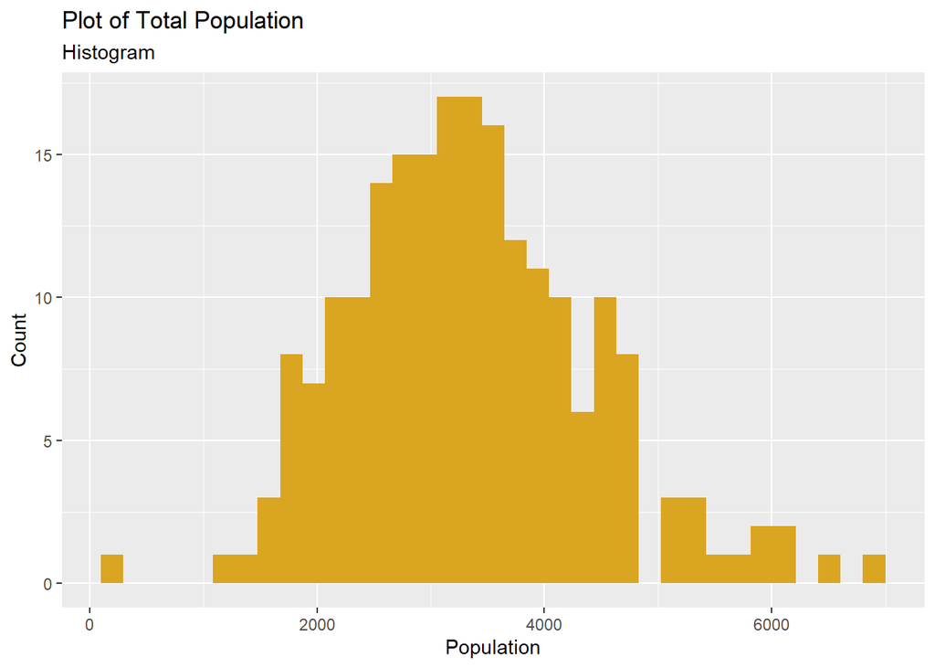

```r
ggplot(data = df) +
  geom_histogram(aes(x = TotalPopulation), bins = 35, fill = "goldenrod", col = NA) +
  labs(title = "Plot of Total Population", subtitle = "Histogram", x = "Population", y = "Count")
```

```r
population_plot = ggplot(df, aes(geometry = geometry, fill = TotalPopulation)) +
  geom_sf(col = NA) +
  coord_sf() +
  scale_fill_viridis_c() +
  labs(title = "Total Population", subtitle = "Spatial Plot",
       xlab = "Longitude", ylab = "Latitude", fill = "Population") +
  theme(legend.position = "top", legend.title.position = "top", plot.margin = unit(c(0.05, 0.05, 0.05, 0.05), "cm"))

ggsave("population_plot.png", plot = population_plot)
```

The above chunk saves the spatial plot to the same folder that this markdown file is in. The file is titled “population_plot.png”